# Practical Machine Learning

#### author: Eeva Rasi

#### date: 26.8.2017

## Problem definition and background

In this project, the goal will be to study Pima Indians Diabetes Database and build a machine learning model to predict whether or not a patient has diabetes.

The dataset contains 9 variables:

- Number of pregnancies
- Glocose
- Blood Pressure
- Skin thickness
- Insulin
- BMI
- Diabetes pedigree function
- Age
- Outcome

The `Outcome` variable shows whether or not a patient has diabetes:

## Data

The dataset for this project are available here:

https://www.kaggle.com/uciml/pima-indians-diabetes-database

```r
# Needed libraries
library(caret)
library(corrplot)
library(xgboost)
library(randomForest)
library(stats)
library(knitr)
library(party)
library(mlbench)

setwd("C:\\WD\\Coursera\\Practical Machine Learning")

# Load CSV file
diabetes.df = read.csv("diabetes.csv", stringsAsFactors=FALSE)
```

## Data Analysis & Cleansing

The training dataset contains 768 observations and 9 features We start cleaning the data by checking and removing near zero variables and checking and removing variables that are mostly NA. This dataset was already clean as `NZV` variable is empty and `naVar` variable is FALSE for all columns.

```r
set.seed(1234)

head(diabetes.df)
```

```
##   Pregnancies Glucose BloodPressure SkinThickness Insulin  BMI
## 1           6     148            72            35       0 33.6
## 2           1      85            66            29       0 26.6
## 3           8     183            64             0       0 23.3
## 4           1      89            66            23      94 28.1
## 5           0     137            40            35     168 43.1
## 6           5     116            74             0       0 25.6
##   DiabetesPedigreeFunction Age Outcome
## 1                    0.627  50       1
## 2                    0.351  31       0
## 3                    0.672  32       1
## 4                    0.167  21       0
## 5                    2.288  33       1
## 6                    0.201  30       0
```

```r
# Check and remove near zero variables
NZV <- nearZeroVar(diabetes.df)
length(NZV)
```

```
## [1] 0
```

```r
# Check and remove variables that are mostly NA
naVar <- sapply(diabetes.df, function(x) mean(is.na(x))) > 0.97
naVar
```

```
##              Pregnancies                  Glucose            BloodPressure
##                    FALSE                    FALSE                    FALSE
##            SkinThickness                  Insulin                      BMI
##                    FALSE                    FALSE                    FALSE
## DiabetesPedigreeFunction                      Age                  Outcome
##                    FALSE                    FALSE                    FALSE
```

We continue by splitting the original dataset into a training set `train.data` and testing set `test.data`.

```r
# Create datasets for training and testing
indTrain  <- createDataPartition(diabetes.df$Outcome, p=0.7, list=FALSE)
train.data <- diabetes.df[indTrain, ]
test.data  <- diabetes.df[-indTrain, ]
```

## Feature Selection

Feature selection is important part of building a prediction model. A correlation matrix can be used to find out relationships between different features. The highly correlated variables are shown in dark colors in the graph below.

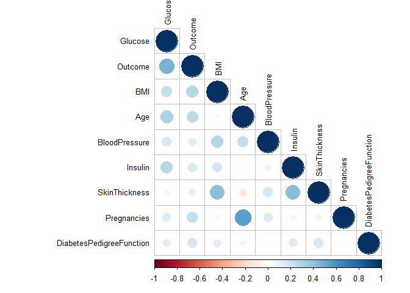

```r
# Correlation matrix
corMatrix <- cor(train.data[, -54])
# Plot correlation
corrplot(corMatrix, order = "FPC", method = "circle", type = "lower",
         tl.cex = 0.8, tl.col = rgb(0, 0, 0))
```

The `caret` package also contains nice tools for feature selection. The importance of features can be estimated by building a model.

```r
# Convert Outcome variable as a factor
train.data$Outcome <- as.factor(train.data$Outcome)
test.data$Outcome <- as.factor(test.data$Outcome)

# Prepare training scheme
control <- trainControl(method="repeatedcv", number=5, repeats=3)
# Train the model
model <- train(Outcome~., data=train.data, method="knn", trControl=control)
# Estimate variable importance
importance <- varImp(model, scale=FALSE)
# Summarize importance
print(importance)
```

```
## ROC curve variable importance
##
##                          Importance
## Glucose                      0.7904
## Age                          0.6953
## BMI                          0.6723
## Pregnancies                  0.6414
## DiabetesPedigreeFunction     0.6085
## BloodPressure                0.6019
## SkinThickness                0.5642
## Insulin                      0.5388
```

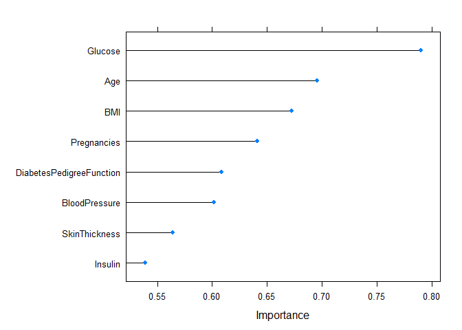

```r
# Plot importance
plot(importance)
```

The correlation plot and a model both show that Glucose, Age and BMI seems to be the most important features.

## Prediction Models

Now we will create a prediction model to predict the `Outcome` variable. I’m using four different out of the box classifiers to find out which classification method suites best for this data. 5-fold cross-validation is also uset with all methods.

```r
set.seed(123)

# Cross-validation
control <- trainControl(method="repeatedcv", number=5, repeats=3)

# K-Nearest Neighbors
modelKNN <- train(Outcome~., data=train.data, method="knn", trControl=control)

# Logistic regression
modelGLM <- train(Outcome~., data=train.data, method="glm", trControl=control)

# Random Forest
modelRF <- train(Outcome~., data=train.data, method="rf", trControl=control)

# Naive Bayes
modelNB <- train(Outcome~., data=train.data, method="nb", trControl=control)

# Collect results
results <- resamples(list(KNN=modelKNN, GLM=modelGLM, RF=modelRF, NB=modelNB))

# Summary
summary(results)
```

```
##
## Call:
## summary.resamples(object = results)
##
## Models: KNN, GLM, RF, NB
## Number of resamples: 15
##
## Accuracy
##          Min.   1st Qu.    Median      Mean   3rd Qu.      Max. NA's
## KNN 0.6448598 0.6958461 0.7222222 0.7262996 0.7570093 0.8037383    0
## GLM 0.7196262 0.7488318 0.7592593 0.7639437 0.7803738 0.8130841    0
## RF  0.6880734 0.7453914 0.7570093 0.7565816 0.7757009 0.8224299    0
## NB  0.6728972 0.7336449 0.7757009 0.7645009 0.7972732 0.8240741    0
##
## Kappa
##          Min.   1st Qu.    Median      Mean   3rd Qu.      Max. NA's
## KNN 0.2246377 0.3068467 0.3835616 0.3813911 0.4631416 0.5358397    0
## GLM 0.3548387 0.4276962 0.4458128 0.4609972 0.5040373 0.5716573    0
## RF  0.2889486 0.4279112 0.4539090 0.4556827 0.5070715 0.6053194    0
## NB  0.2900474 0.4196603 0.4955157 0.4769553 0.5434565 0.6023256    0
```

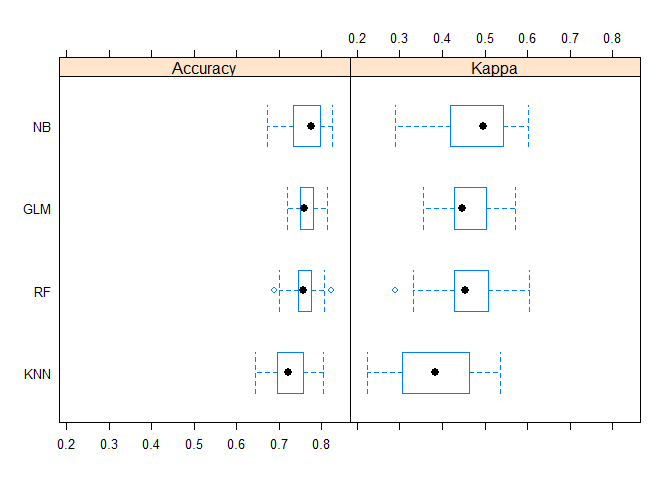

```r
# Plot results
bwplot(results)
```

The Naive Bayes and Logistic Regression seems to be best methods. Finally we will use our models to predict `Outcome` variable in `test.data` dataset.

```r
# Predict the Outcome variable with Naive Bayes
predictNB <- predict(modelNB, newdata=test.data)
confNB <- confusionMatrix(predictNB, test.data$Outcome)
confNB
```

```
## Confusion Matrix and Statistics
##
##           Reference
## Prediction   0   1
##          0 126  36
##          1  27  41
##
##                Accuracy : 0.7261
##                  95% CI : (0.6636, 0.7826)
##     No Information Rate : 0.6652
##     P-Value [Acc > NIR] : 0.02814
##
##                   Kappa : 0.3666
##  Mcnemar's Test P-Value : 0.31350
##
##             Sensitivity : 0.8235
##             Specificity : 0.5325
##          Pos Pred Value : 0.7778
##          Neg Pred Value : 0.6029
##              Prevalence : 0.6652
##          Detection Rate : 0.5478
##    Detection Prevalence : 0.7043
##       Balanced Accuracy : 0.6780
##
##        'Positive' Class : 0
##
```

```r
# Predict the Outcome variable with Logistic Regression
predictGLM <- predict(modelGLM, newdata=test.data)
confGLM <- confusionMatrix(predictGLM, test.data$Outcome)
confGLM
```

```
## Confusion Matrix and Statistics
##
##           Reference
## Prediction   0   1
##          0 137  35
##          1  16  42
##
##                Accuracy : 0.7783
##                  95% CI : (0.719, 0.8302)
##     No Information Rate : 0.6652
##     P-Value [Acc > NIR] : 0.0001172
##
##                   Kappa : 0.4697
##  Mcnemar's Test P-Value : 0.0117187
##
##             Sensitivity : 0.8954
##             Specificity : 0.5455
##          Pos Pred Value : 0.7965
##          Neg Pred Value : 0.7241
##              Prevalence : 0.6652
##          Detection Rate : 0.5957
##    Detection Prevalence : 0.7478
##       Balanced Accuracy : 0.7204
##
##        'Positive' Class : 0
##
```